# Graphical options with `plot_fullsibQTL`

In this short tutorial we show how to plot different graphics using function `plot_fullsibQTL`. A complete description can be obtained with `?plot_fullsibQTL`.

As an example we will use the example data that comes with the package, and the using the QTL model. The following steps, preceding the graphical part, are detailed in the vignette *`fullsibQTL` Tutorial*.

```r
  library( "fullsibQTL" )
  data( "example_QTLfullsib" )
  fullsib <- create_fullsib( example_QTLfullsib,
                             list( LG1_final, LG2_final, LG3_final, LG4_final ),
                             step = 1,
                             map.function = "kosambi",
                             condIndex = 3.5 )

  ## IM
  im <- im_scan( fullsib )
  qtls.im <- r2_ls( fullsib,
                    pheno.col = 1,
                    lg = c( 1, 1, 2, 2, 2, 3, 3, 4 ),
                    pos = c( "loc13", "M12", "loc45", "loc77", "loc108", "M33", "loc65", "M52" ) )

  ## CIM
  cofs.fs <- cof_selection( fullsib,
                            pheno.col = 1,
                            k=log(300),
                            n.cofactor = 10)
  cim <- cim_scan( cofs.fs )
  qtls.cim <- r2_ls( fullsib,
                     pheno.col = 1,
                     lg = c( 1, 1, 2, 2, 2, 3, 3, 4 ),
                     pos = c( "loc13", "M12", "loc45", "loc77", "loc108", "M33", "loc65", "M52" ) )

  ## Getting im and cim peaks for alpha 0.05.
  im.peak1 <- summary( im_perm, alpha = 0.05 )[ 1, 1 ]
  im.peak2 <- summary( im_perm, alpha = 0.05 )[ 1, 2 ]

  cim.peak1 <- summary( cim_perm, alpha = 0.05 )[ 1, 1 ]
  cim.peak2 <- summary( cim_perm, alpha = 0.05 )[ 1, 2 ]
```

## Customizing the Graphics

The minimal plot requires a fullsib object, and at least one result of doing a genome scan with `fullsib_scan`. The genetic map is on the X axis.

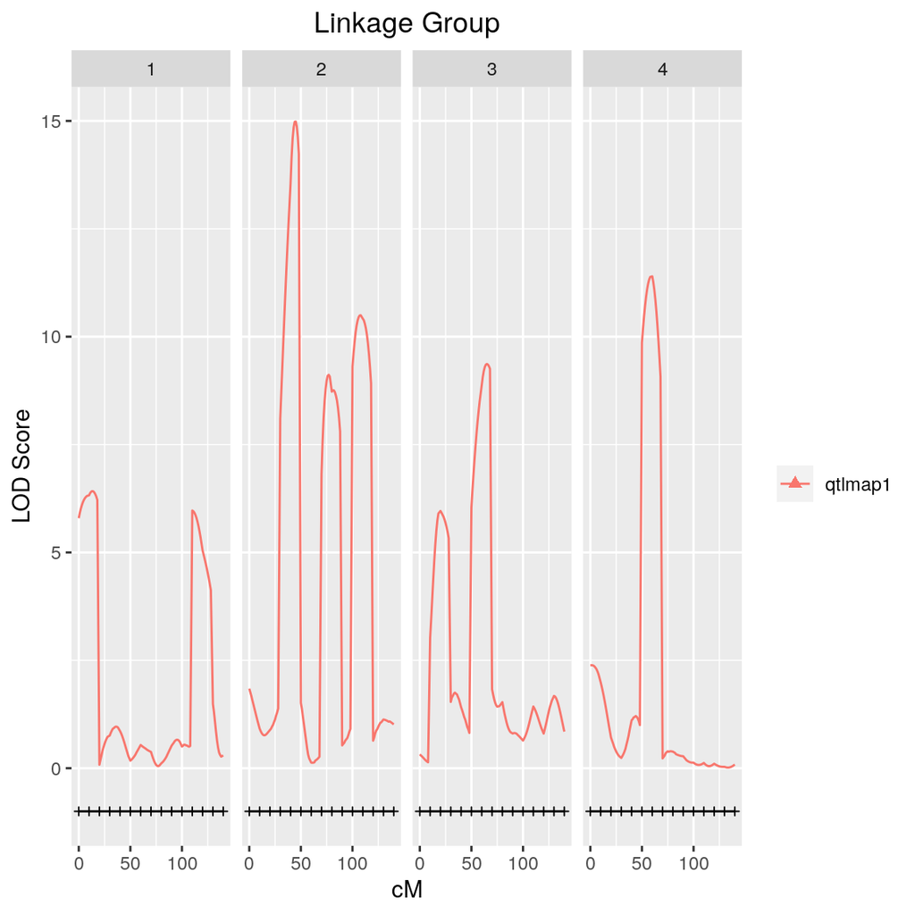

```r
plot_fullsibQTL( fullsib = fullsib,
                 fullsib.scan = cim )
```

We can set the legend of the QTL mapping including the `qtlmapping` option:

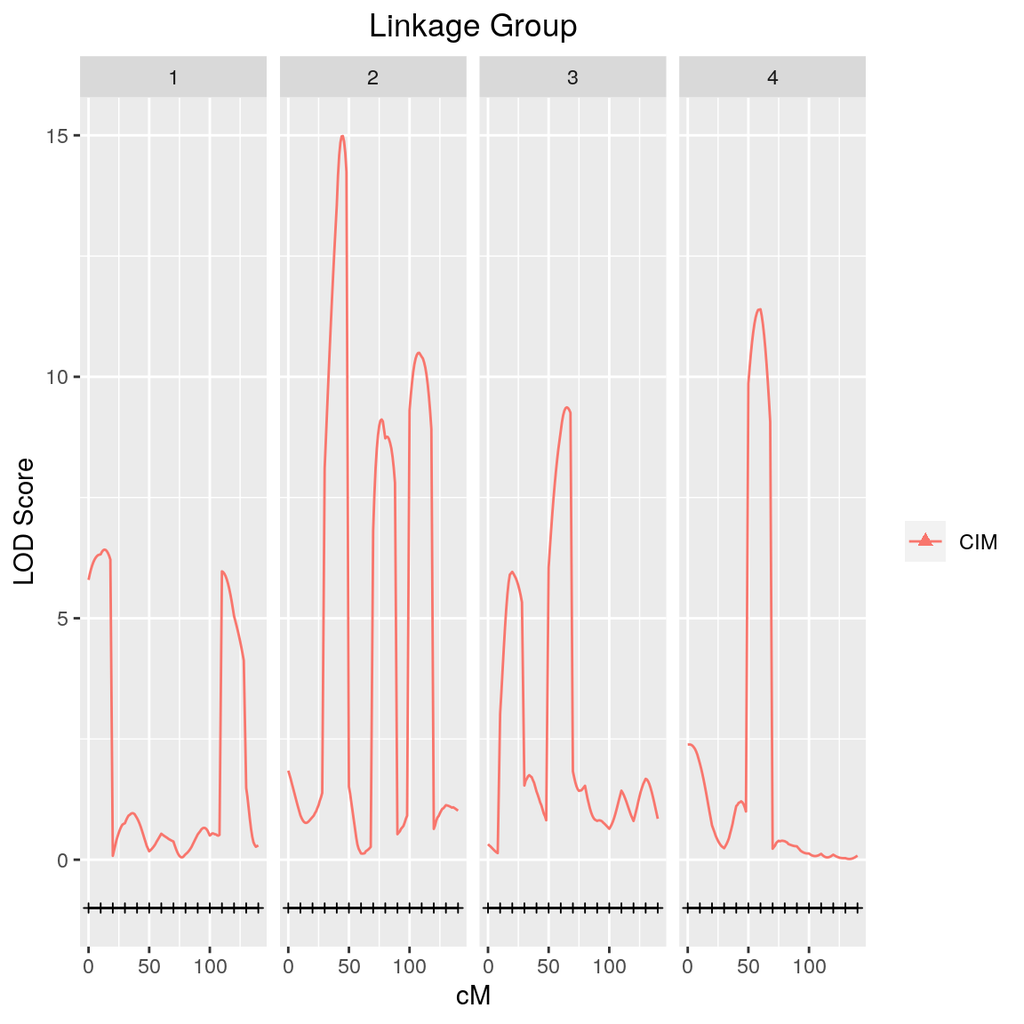

```r
plot_fullsibQTL( fullsib = fullsib,
                 fullsib.scan = cim,
                 qtlmapping = "CIM" )
```

## Graphical comparision between `im_scan` and `cim_scan`

It is possible to plot a graphic with both strategies. To do this, one should use a list with previous analysis with each model. (see the `list()` in the arguments). Those multiple results can be, for example, different models (IM and CIM), traits, the same trait in different environments, etc.

For example, to include results of IM and CIM:

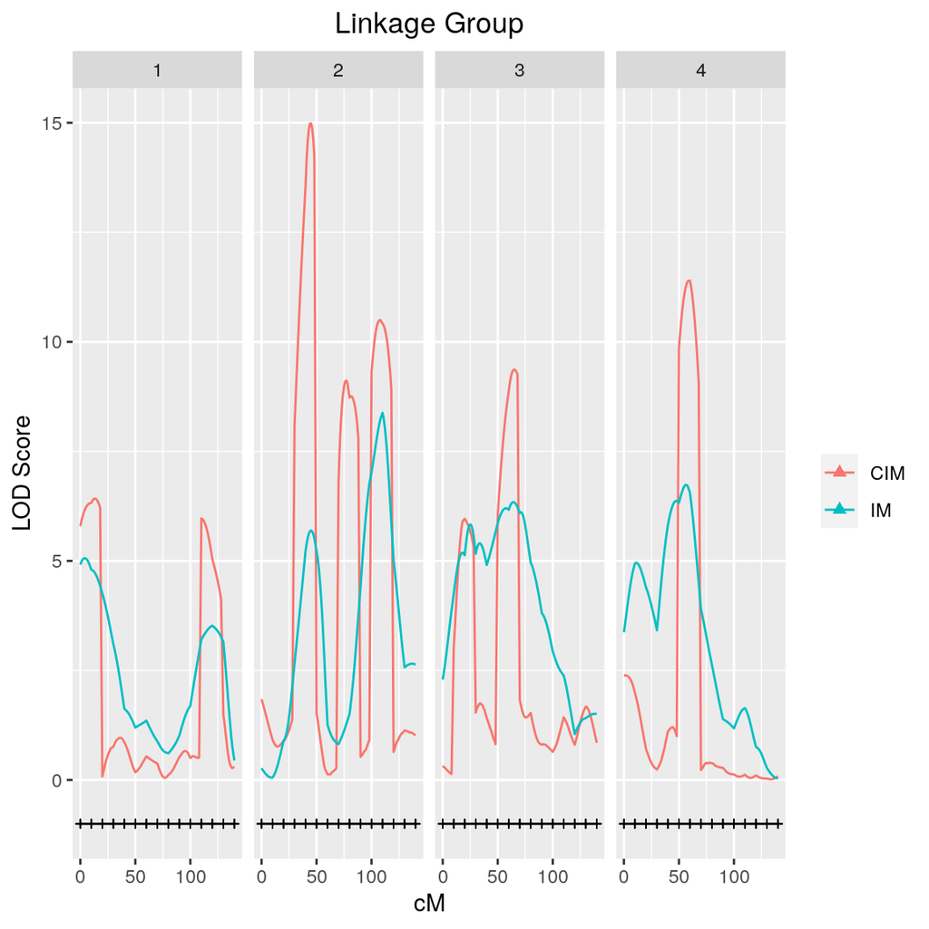

```r
plot_fullsibQTL( fullsib=fullsib,
                 fullsib.scan=list(cim,im),
                 qtlmapping = c( "CIM", "IM" ) )
```

Of course, both models were adjusted on previous rounds of analysis.

## Adding QTL location

You can insert the QTLs position from the `r2_ls` function for each one of the models. This is done with argument `r2ls.out`. For example, in two different situations:

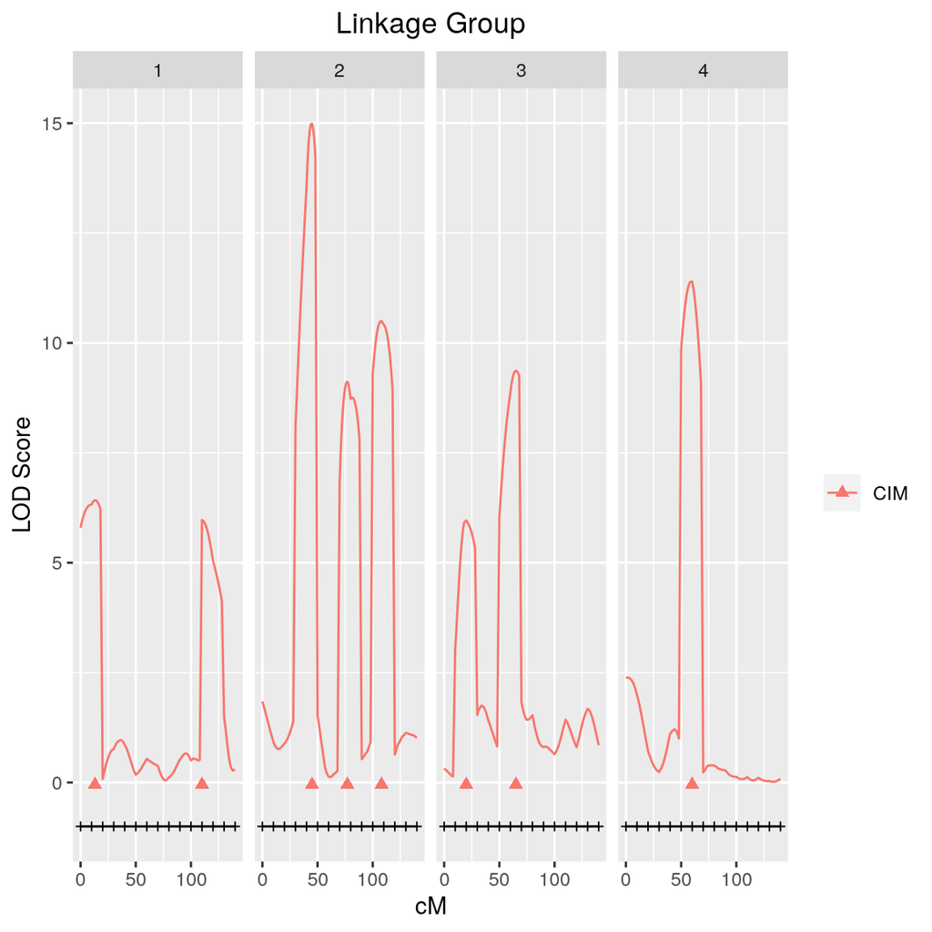

```r
plot_fullsibQTL( fullsib = fullsib,
                 fullsib.scan = cim,
                 r2ls.out = qtls.cim,
                 qtlmapping = "CIM" )
```

For multiple QTLs mappings:

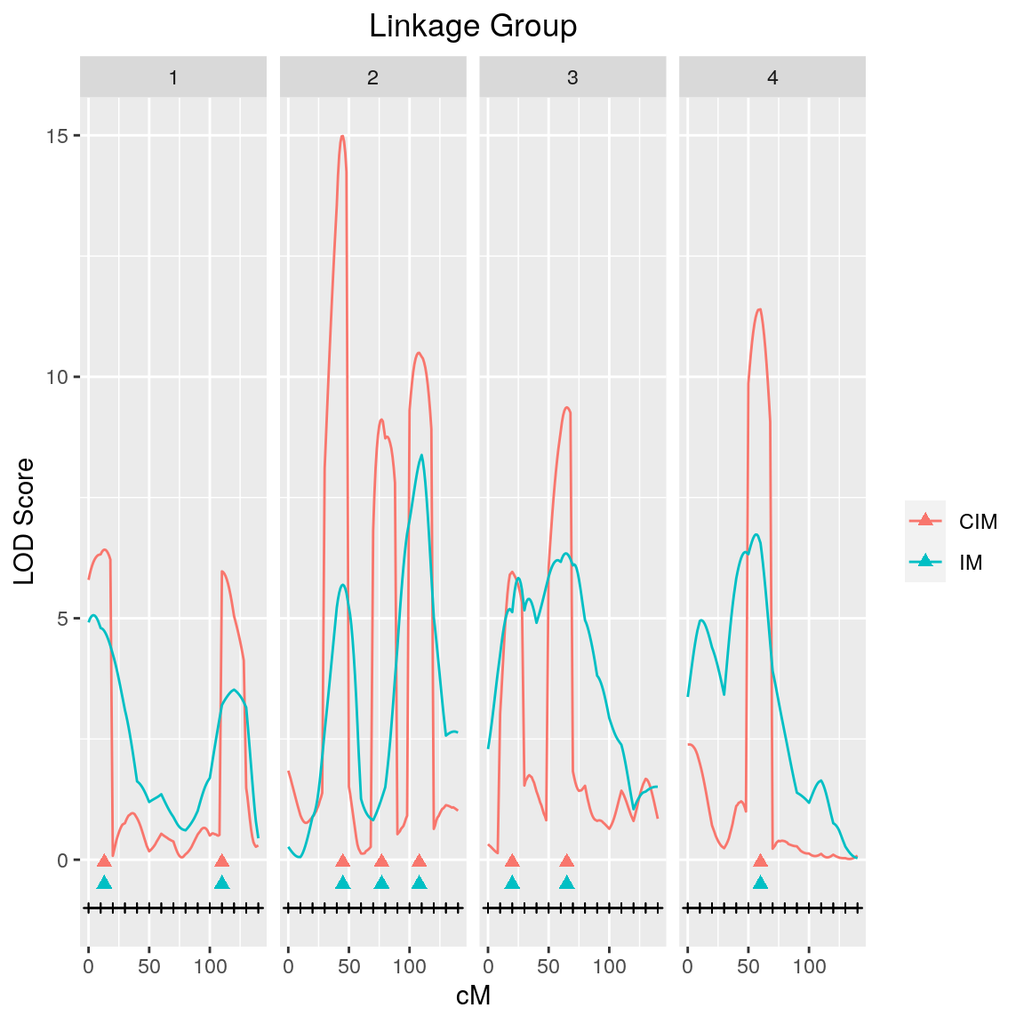

```r
plot_fullsibQTL( fullsib = fullsib,
                 fullsib.scan = list( cim, im ),
                 r2ls.out = list( qtls.cim, qtls.im ),
                 qtlmapping = c( "CIM", "IM" ) )
```

```r
summary( cim_perm )
```

```
#>  Threshold considering 1000 permutations
#>        peak.1   peak.2   peak.3   peak.4
#> 0.05 4.023724 2.900906 2.300657 1.860476
#> 0.1  3.707559 2.650663 2.140063 1.692707
```

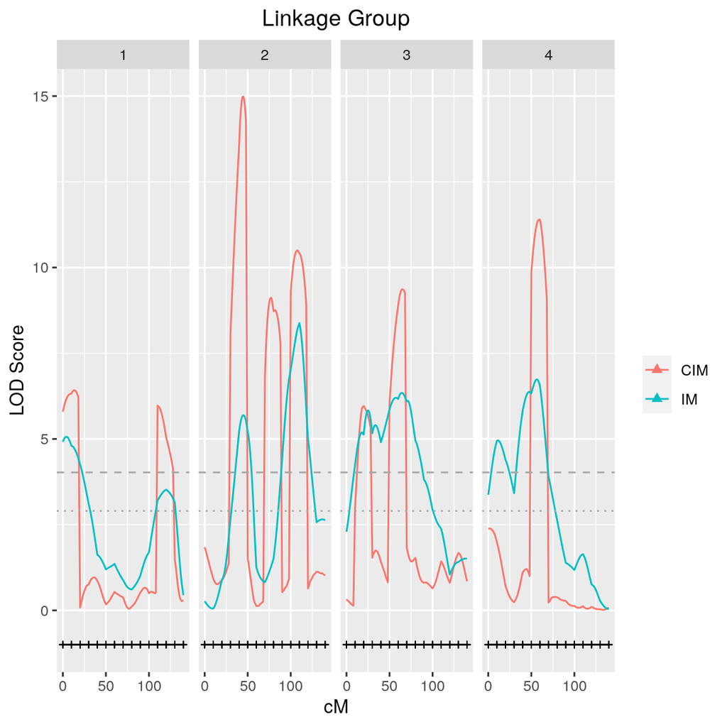

```r
plot_fullsibQTL( fullsib = fullsib,
                 fullsib.scan = list ( cim, im ),
                 qtlmapping = c( "CIM", "IM" ),
                 thr = c(4.023724, 2.900906 ) )
```

It is also possible to use a grayscale:

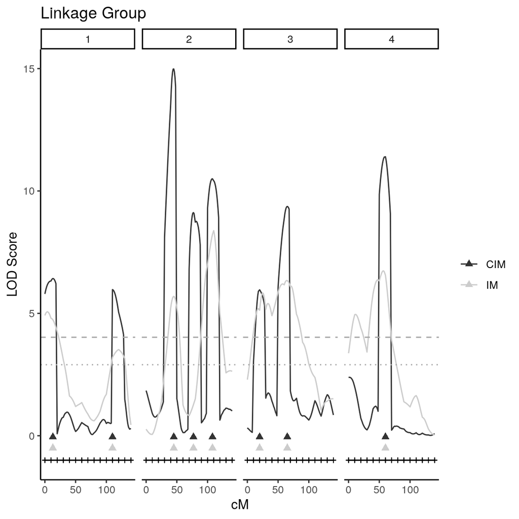

```r
plot_fullsibQTL( fullsib = fullsib,
                 fullsib.scan = list( cim, im ),
                 r2ls.out = list( qtls.cim, qtls.im ),
                 qtlmapping = c( "CIM", "IM" ),
                 thr = c( 4.023724, 2.900906 ),
                 grayscale = TRUE )
```

Moreover, one might want to see only selected linkage groups. For example, for LG 2:

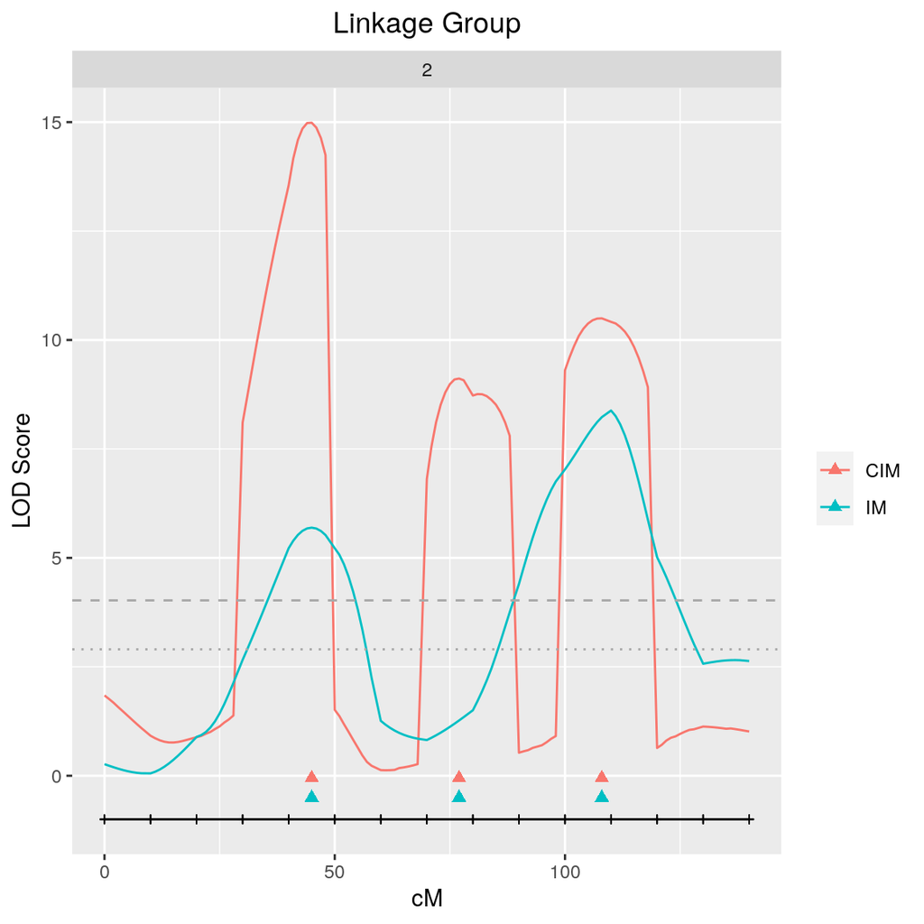

```r
plot_fullsibQTL( fullsib = fullsib,
                 fullsib.scan = list( cim, im ),
                 r2ls.out = list( qtls.cim, qtls.im ),
                 qtlmapping = c( "CIM", "IM" ),
                 thr = c( 4.023724, 2.900906 ),
                 lgs = 2 )
```

For LGs 2 and 4:

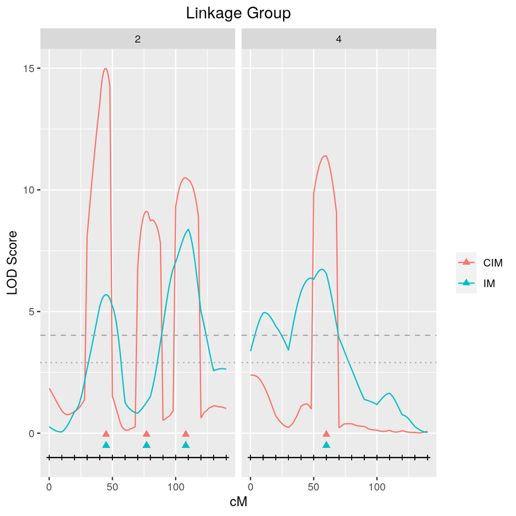

```r
plot_fullsibQTL( fullsib = fullsib,
                 fullsib.scan = list( cim, im ),
                 r2ls.out = list( qtls.cim, qtls.im ),
                 qtlmapping = c( "CIM", "IM" ),
                 thr = c( 4.023724, 2.900906 ),
                 lgs = c( 2, 4 ) )
```

## Interactive plots

A very useful feature is to plot interactive graphics. Function ‘plot_fullsibQTL’ uses internally the great package `plotly` as its engine. With option `interact=TRUE`, an interactive `html` graphic will be created in the working directory (or any arbitrary one defined by the user). The plot will automatically open in the default browser (for not doing so, set `browser=FALSE`).

```r
## Setting the file name
plot_fullsibQTL( fullsib = fullsib,
                 fullsib.scan = list( cim, im ),
                 r2ls.out = list( qtls.cim, qtls.im ),
                 qtlmapping = c ( "CIM", "IM" ),
                 thr = c( 4.023724, 2.900906 ),
                 interact = TRUE,
                 file = "cim_im.html" )

## Setting the folder name
plot_fullsibQTL( fullsib = fullsib,
                 fullsib.scan = list( cim, im ),
                 r2ls.out = list( qtls.cim, qtls.im ),
                 qtlmapping = c( "CIM", "IM" ),
                 thr = c( 4.023724, 2.900906 ),
                 interact = TRUE,
                 file = "cim_im.html",
                 folder = "/home/your_user_name/graphics" )

## Setting to not open the browser
plot_fullsibQTL( fullsib = fullsib,
                 fullsib.scan = list( cim, im ),
                 r2ls.out = list( qtls.cim, qtls.im ),
                 qtlmapping = c( "CIM", "IM" ),
                 thr = c( 4.023724, 2.900906 ),
                 interact = TRUE,
                 file = "cim_im.html",
                 folder = "/home/your_user_name/Pictures",
                 browser = FALSE )
```

The script above creates a graphic that can be visualized clicking [here](https://rramadeu.github.io/fullsibQTL/vignettes_highres/graphics/cim_im.html). It is a interactive `plotly` graphic. *Click on legend entries to toggle traces, click-and-drag on the chart to zoom, double-click to autoscale, shift-and-drag to pan* (from [plotly website](https://plot.ly/r/getting-started/)). Additionally, it also has in the tooltip the LOD score, the QTL estimated effect, and marker names in the genetic map.

The user can also set the height and width of the interactive plot, with arguments `height` and `width` (they are the same as the arguments of `plotly` function). The default of `height` is 500 pixels and for `width` is 250 $\times$ the number of LGs to be plot. All the arguments can be combined in the interactive plot.

## Changing colors

There is and option to choose the colors for each linkage group, with argument `lg.colors`, that will pass its values to the `ggplot2::scale_colour_manual` function. You can check more colors options at [cheatsheet](https://www.nceas.ucsb.edu/~frazier/RSpatialGuides/colorPaletteCheatsheet.pdf) or at this color [guide](http://www.stat.columbia.edu/~tzheng/files/Rcolor.pdf).

```r
plot_fullsibQTL( fullsib = fullsib,
                 fullsib.scan = list( cim, im ),
                 r2ls.out = list( qtls.cim, qtls.im ),
                 qtlmapping = c( "CIM", "IM" ),
                 thr = c( 4.023724, 2.900906 ),
                 lgs = c( 2, 4 ),
                 interact = TRUE,
                 lg.colors = c( "darkgreen", "green" ),
                 height = 600,
                 width = 800,
                 file = "cim_im_greens.html",
                 folder="/home/your_user_name/graphics" )
```

The graphic is here: cim_im_greens.html